# Глава 9

Добро пожаловать Организации любого размера активно инвестируют в виртуализацию и облачные вычисления. Поэтому ИТ-специалистам важно разбираться в этих двух технологиях. Несмотря на некоторые общие черты, это, по сути, две разные технологии. ПО виртуализации позволяет развернуть на одном физическом сервере несколько отдельных вычислительных сред. Термин «облачные вычисления» используется для описания доступности общих вычислительных ресурсов, ПО или данных, предоставляемых в качестве услуги и по требованию через Интернет.

В этой главе вы узнаете о преимуществах виртуализации по сравнению с традиционным использованием выделенных серверов. Среди преимуществ — сокращение потребности в ресурсах и свободном пространстве, снижение затрат, увеличение времени безотказной работы серверов и другие. Вы также узнаете, какие термины используются в контексте виртуализации на стороне клиента, например хост-компьютер — физический компьютер под управлением пользователя. ОС хоста — это ОС на хост-компьютере, а гостевая ОС — ОС на виртуальной машине, работающей на хост-компьютере.

Важно не только получить теоретические знания о виртуализации и облачных технологиях, но и приобрести практические навыки. В этой главе вы выполните лабораторную работу по установке Linux на виртуальной машине.

Видео. Что такое облако? Нажмите кнопку воспроизведения на рисунке, чтобы посмотреть видео, посвященное облаку. Видео. Что такое облако? (3,5 мин.) Приходилось ли вам терять важную информацию, например документы, фотографии или музыкальные файлы, из-за какого-то инцидента с компьютером или мобильным устройством? Даже если у вас есть резервная копия, восстановление потерянных данных и приложений на другом компьютере может потребовать много времени и затрат. А возникала ли у вас ситуация, когда вам был нужен доступ к информации на конкретном компьютере, находящемся вне досягаемости? Или у вас был USB-накопитель с данными, но получить к ним доступ было невозможно из-за отсутствия необходимого приложения на компьютере. Обычно данные и программы хранятся на жестком диске компьютера, то есть в локальном хранилище. При таком варианте возможна ситуация, когда данные и необходимые для их использования приложения потеряны или недоступны. А теперь представьте себе, что доступ ко всей информации, данным и приложениям можно получить по сети — в облаке. В этом случае информация хранится не на компьютере, а в другом месте, с возможностью удаленного доступа по сети и, как правило, через Интернет. Можно сравнить это с удаленным жестким диском, доступным в любое время и в любой точке. Многие приложения можно открывать с помощью веб-браузера. Их называют веб-приложениями. Вебприложение находится на удаленном сервере и доступно через веб-браузер, такой как Chrome или Firefox. Типичные примеры веб-приложений — Google Документы, Google Фото, Office 365. Облако также предоставляет ресурсы для удаленного хранения и совместного использования файлов. Это, например, сервисы Google Диск, Dropbox и Microsoft OneDrive. Рекомендуется создавать резервные копии информации в локальном хранилище либо в облачном сервисе. Что произойдет, если облачный сервис перестанет работать? Как вернуть свои данные? И возможно ли это вообще? Нужно проявлять осторожность, доверяя свою информацию третьей стороне. Принимает ли эта сторона необходимые меры предосторожности для защиты ваших данных? Что будет, если поставщик облачного сервиса потеряет ваши данные или подвергнется взлому и постороннее лицо получит доступ ко всей вашей информации? В последние несколько лет пользователи и компании все чаще переходят на облачные сервисы. Облако предлагает множество преимуществ: постоянная доступность, повсеместный доступ к данным в любое время, отсутствие проблем, связанных с единичной точкой отказа и возможностью получить доступ к данным или ПО только с одного устройства или компьютера, улучшение совместной работы, упрощение обмена информацией между пользователями и обслуживания ПО, поскольку оператор облачного сервиса выполняет все задачи по обновлению и обслуживанию ПО. Суть в том, что подобные сервисы находятся вне вашей среды и, поскольку они традиционно изображались на топологических схемах в виде облака, теперь мы называем такие сервисы «облачными».

[figure not shown]

[9.1.1.1](https://contenthub.netacad.com/legacy/ITE/7.01/ru/course/module9/9.1.1.1/9.1.1.1.html?wvideo=pml2gzf8gl)

Облачные вычисления и виртуализация Понятия «виртуализация» и «облачные вычисления» зачастую используются как взаимозаменяемые, но на самом деле они означают разные вещи.

Виртуализация позволяет разместить на одном физическом компьютере (хост-компьютере) несколько независимых виртуальных компьютеров, совместно использующих оборудование хост-компьютера. ПО виртуализации отделяет физическое оборудование от экземпляров виртуальных машин (ВМ). ВМ имеют собственные операционные системы и получают доступ к аппаратным ресурсам через ПО, работающее на хост-компьютере. Образ ВМ можно сохранить в виде файла и при необходимости запустить снова.

Важно помнить, что все ВМ совместно используют ресурсы хост-компьютера. Поэтому число ВМ, которые могут работать одновременно, напрямую зависит от мощности процессора, объема памяти и устройства хранения данных.

Облачные вычисления отделяют приложения от аппаратных средств. Они обеспечивают организациям сетевой доступ к вычислительным сервисам по требованию. Поставщики услуг, такие как Amazon Web Services (AWS), являются владельцами и управляющими облачной инфраструктуры, которая включает в себя сетевые устройства, серверы и устройства хранения данных и обычно размещается в центре обработки данных (ЦОД).

Виртуализация — это основа облачных вычислений. Для предложения облачных сервисов поставщики типа AWS используют мощные серверы, которые могут динамически выделять ресурсы виртуальных серверов по мере необходимости.

Без виртуализации облачные вычисления и их широчайшее внедрение были бы невозможны.

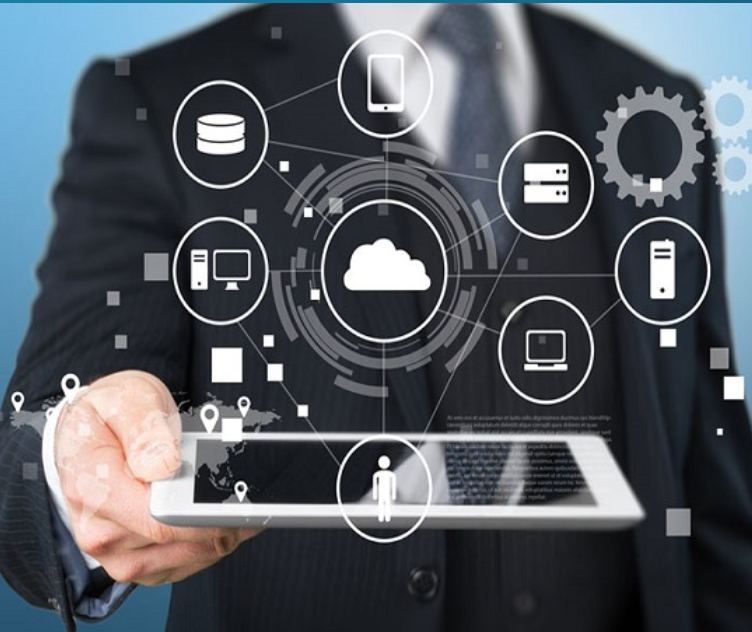

Традиционное развертывание серверов Чтобы составить полное представление о виртуализации, необходимо сначала понять, как используются серверы в организации.

Традиционно организации предоставляли пользователям приложения и сервисы с помощью мощных выделенных серверов, показанных на рисунке. Эти серверы под управлением Windows и Linux представляют собой высокопроизводительные компьютеры с большим объемом ОЗУ, мощными процессорами и несколькими емкими устройствами хранения данных. Если число пользователей увеличивается или необходимы новые сервисы, добавляются новые серверы.

Проблемы, связанные с традиционным подходом к развертыванию серверов:

Неэффективная трата ресурсов из-за того, что выделенные серверы долго простаивают, пока не потребуется предоставляемый ими сервис. Во время простоя эти серверы потребляют энергию. Единая точка отказа — возникает при сбое или отключении выделенного сервера от сети. Резервные серверы для переключения при отказе отсутствуют. Бесконтрольный рост количества серверов — возникает, когда организации не хватает площадей, чтобы физически разместить недозагруженные серверы. Серверы занимают больше пространства, чем это оправдано сервисами, которые они предоставляют. Виртуализация серверов для более эффективного использования ресурсов решает эти проблемы.

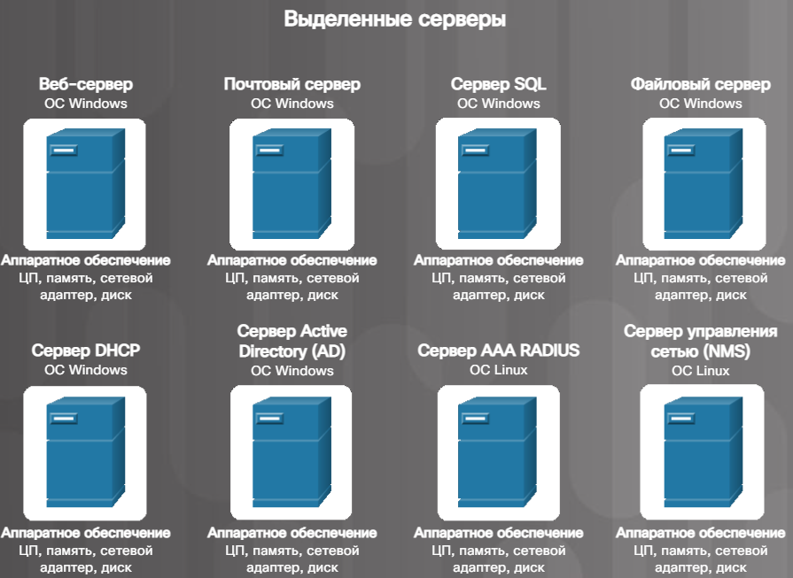

Виртуализация серверов Виртуализация серверов позволяет использовать незадействованные ресурсы, чтобы сократить число серверов, необходимых для предоставления сервисов пользователям.

Специальная программа, называемая гипервизором, управляет ресурсами компьютера и различными ВМ. Она обеспечивает ВМ доступ ко всем аппаратным компонентам физического компьютера — ЦП, памяти, дисковым контроллерам и сетевым адаптерам. Каждая ВМ использует полноценную и отдельную операционную систему.

Благодаря виртуализации предприятия могут консолидировать серверы. Например, нередки случаи консолидации 100 физических серверов в качестве виртуальных машин на 10 физических серверах с использованием гипервизоров. На рисунке восемь выделенных серверов из предыдущей конфигурации объединены в два сервера с помощью гипервизоров для поддержки нескольких виртуальных экземпляров операционных систем.

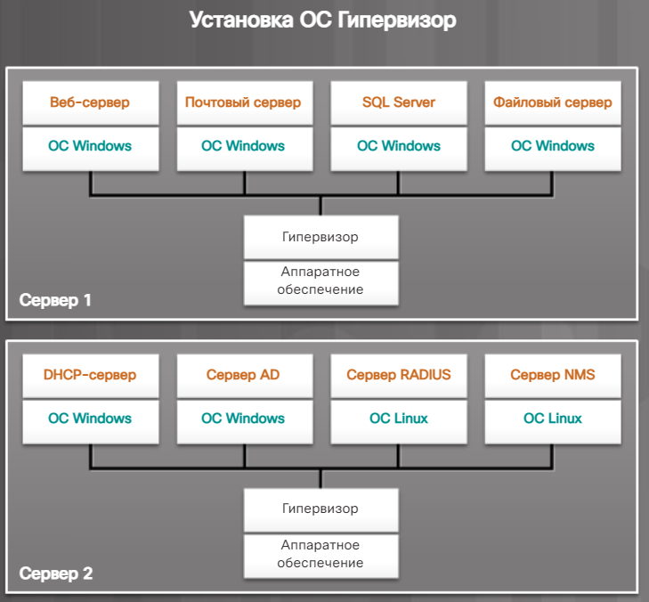

Более эффективное использование ресурсов. Виртуализация сокращает число физических серверов и сетевых устройств, объемы вспомогательной инфраструктуры и затраты на обслуживание.

Уменьшение энергопотребления.Консолидация серверов снижает ежемесячные расходы на электроэнергию и охлаждение. Уменьшение энергопотребления помогает предприятиям сократить выбросы парниковых газов.

Ускоренное выделение серверных ресурсов. Создание виртуального сервера занимает гораздо меньше времени, чем выделение ресурсов физического сервера.

Улучшенное восстановление после сбоев.Виртуализация предусматривает передовые решения, позволяющие компаниям продолжать работу во время сбоя. ВМ можно скопировать на другие аппаратные платформы, которые могут находиться даже в другом ЦОД.

Сокращение требований к свободному пространству.Консолидация серверов с виртуализацией сокращает общую площадь, занимаемую ЦОД. Чем меньше серверов, сетевых устройств и стоек, тем меньше требуется свободного пространства.

Снижение затрат.Экономия достигается за смет сокращения потребностей в оборудовании и свободном пространстве, а также благодаря снижению энергопотребления.

Увеличение времени безотказной работы серверов.Большинство платформ для виртуализации серверов сегодня обладает расширенными средствами отказоустойчивости, такими как динамическая миграция, миграция хранилища, высокая доступность и распределенное планирование ресурсов. Они также позволяют перенести виртуальную машину с одного сервера на другой.

Поддержка существующих систем.Виртуализация может продлить срок службы ОС и приложений, предоставляя организациям больше времени для перехода на новые решения.

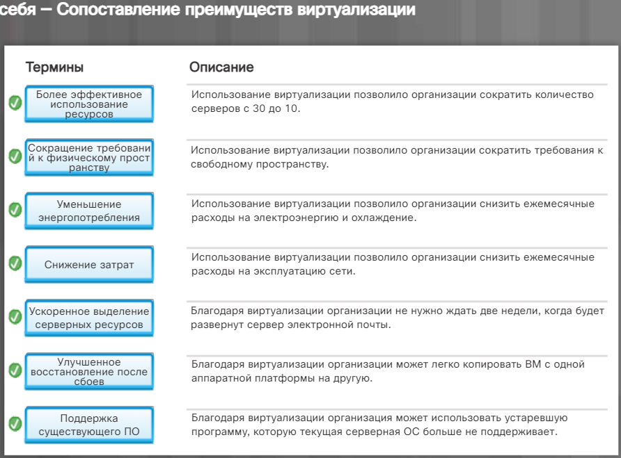

Виртуализация на стороне клиента Многие организации используют виртуализацию серверов для оптимизации сетевых ресурсов и снижения затрат на оборудование и обслуживание. Кроме того, виртуализация на стороне клиента позволяет пользователям с конкретными потребностями запускать ВМ на своих локальных компьютерах.

Виртуализация на стороне клиента полезна для ИТ-персонала, сотрудников службы ИТ-поддержки, разработчиков и тестировщиков ПО, а также для образовательных целей. Она обеспечивает пользователей ресурсами для тестирования новых операционных систем и программ и для работы с устаревшим ПО. Виртуализацию на стороне клиента можно также использовать для создания песочницы — защищенной изолированной среды для открытия или запуска подозрительных файлов.

Ниже приведены некоторые термины, которые используются в контексте виртуализации на стороне клиента.

Хост-компьютер — физический компьютер под управлением пользователя. ВМ используют системные ресурсы хост-компьютера для загрузки и работы ОС. Операционная система (ОС) хоста — операционная система хост-компьютера. С помощью эмулятора виртуализации, например VirtualBox, в ОС хоста пользователи могут создавать ВМ и управлять ими. Гостевая операционная система — операционная система, работающая на ВМ. Для запуска другой версии ОС требуются соответствующие драйверы. Гостевая ОС не зависит от ОС хоста. Например, в качестве ОС хоста может использоваться Windows 10, а на ВМ может быть установлена Windows 7. Тогда гостевой ОС ВМ будет Windows 7. В данном примере гостевая ОС (Windows 7) не влияет на работу ОС хоста (Windows 10) на хост-компьютере.

ОС хоста и гостевая ОС необязательно должны относиться к одному семейству. Например, в качестве ОС хоста может использоваться Windows 10, а в качестве гостевой ОС — Linux. Это преимущество позволяет пользователям расширить функционал хост-компьютера, запуская сразу несколько операционных систем.

На рисунке представлена логическая схема виртуальных машин. Нижний серый прямоугольник обозначает физический компьютер с ОС хоста (например, Windows 10). Hyper-V, Virtual PC и VirtualBox — примеры ПО виртуализации или эмуляторов, с помощью которых можно создать три ВМ, показанные в верхней части рисунка, и управлять этими ВМ.

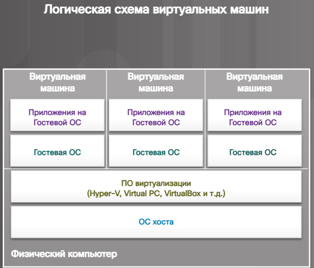

Гипервизоры типа 1 и типа 2 Гипервизор, также называемый диспетчером виртуальных машин (Virtual Machine Manager, VMM) — это мозговой центр виртуализации. Гипервизор — это программа на хост-компьютере, которая используется для создания ВМ и управления ими.

По мере необходимости гипервизор распределяет между ВМ физические системные ресурсы — ЦП, ОЗУ и хранилища. Это гарантирует, что работа одной виртуальной машины не влияет на работу других.

Существует два типа гипервизоров, как показано на рисунке 1.

Гипервизор типа 1 (собственный) — его также называют автономным и обычно используют при виртуализации серверов. Он работает непосредственно на оборудовании хоста и управляет распределением системных ресурсов между виртуальными операционными системами. Гипервизор типа 2 (на основе базовой ОС) — размещается на базе ОС и обычно используется при виртуализации на стороне клиента. Примерами гипервизора типа 2 являются программы виртуализации, такие как Windows Hyper-V и VMware Workstation. Гипервизоры типа 1 часто используются в центрах обработки данных и средах облачных вычислений. Примеры гипервизоров типа 1 — VMware vSphere, ESXi, Xen и Oracle VM Server.

Гипервизоры типа 2, такие как VMware Workstation, работают на хост-компьютере для создания и использования нескольких ВМ. Гипервизор Windows Hyper-V входит в ОС Windows 10 Pro и Windows Server (2012 и 2016).

Эмуляторы на стороне клиента могут использовать ПО, предназначенное для другой гостевой ОС, или ОС, предназначенную для другого оборудования. Например, если ОС хоста — Linux и создается ВМ под управлением Windows 7 для запуска приложения, предназначенного только для Windows 7. Хост-компьютер с ОС Linux будет «имитировать» компьютер с ОС Windows 7.

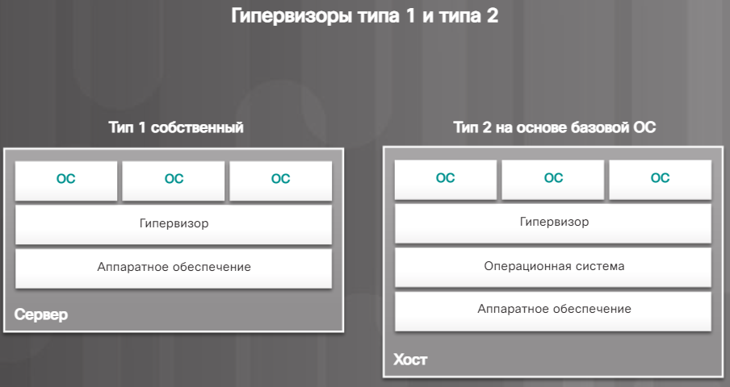

ребования для виртуальных машин Для виртуальной вычислительной среды требуются более мощные конфигурации оборудования, так как каждая установка нуждается в собственных ресурсах.

Основные системные требования одинаковы для всех виртуальных машин.

ВМ уязвимы для тех же угроз и атак, что и физический компьютер. Хотя ВМ изолированы от хоста, они могут совместно использовать ресурсы (например, сетевой адаптер, папки и файлы). Пользователи должны принять для ВМ те же меры безопасности, что и для хоста, и установить ПО безопасности, включить функции межсетевого экрана, регулярно устанавливать исправления и обновления операционной системы и программ. Важно также регулярно обновлять ПО виртуализации.

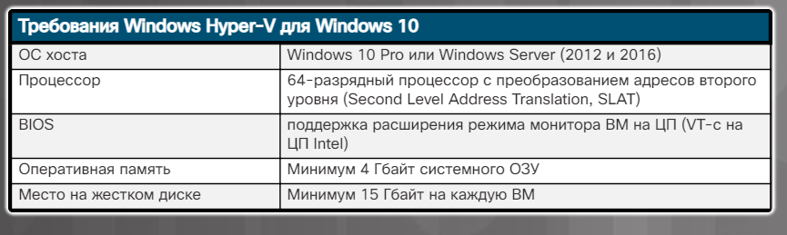

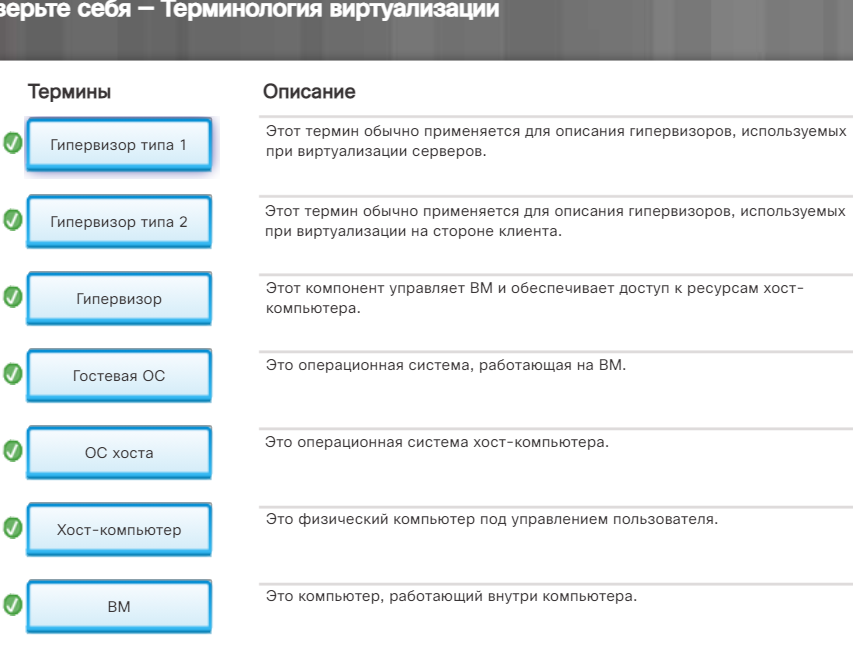

Лабораторная работа. Установка Linux на виртуальной машине и изучение графического интерфейса пользователя В этой лабораторной работе вы установите ОС Linux на виртуальной машине с помощью приложения для виртуализации рабочих столов, такого как VirtualBox. По завершении установки вы изучите графический интерфейс пользователя (GUI). "9.1.2.5 Lab - Install Linux in a Virtual Machine and Explore the GUI"

Как мы используем облако

Потоковая передача виртуальных приложений и облачные приложения.Организации используют облачные приложения для предоставления пользователям ПО по требованию. Например, Microsoft Office 365 включает онлайн-версии приложений Microsoft Word, Excel и PowerPoint. Когда пользователь запрашивает приложение, на клиент пересылается минимальный код приложения. При необходимости клиент получает дополнительный код с облачного сервера. Для работы в автономном режиме приложение можно сохранить локально на хосте.

Облачная электронная почта.Организации используют облачные решения для работы с электронной почтой. Примеры облачных приложений электронной почты: Office 365, Gmail, Почта iCIoud, Outlook, Yahoo и Exchange Online.

Виртуальный рабочий стол (инфраструктура VDI).С помощью этой технологии организация может развертывать полноценные среды рабочих столов с сервера в центре обработки данных на клиентах. Виртуальные рабочие столы создает ВМ под управлением гипервизора. Однако все вычислительные процессы VDI выполняются на серверах. Инфраструктура VDI может быть сохраняемой (в этом случае пользователь получает настраиваемый образ, который можно сохранить на будущее) и несохраняемой (в этом случае образ возвращается в первоначальное состояние при выходе пользователя из системы).

Облачные решения для хранения файлов.Организации используют облачные решения для хранения корпоративных данных. Пример облачных решений для хранения данных: Google Диск, OneDrive, iCIoud Drive, Box и Dropbox. Некоторые из этих решений включают приложения синхронизации, которые предоставляются поставщиками или имеются в продаже.

Виртуальный рабочий стол Windows (WVD). Это выпуск Windows 10 с поддержкой виртуальных рабочих столов, который выполняется на современных или устаревших компьютерах либо удаленно на виртуальных машинах Azure. Он создает виртуализированную среду Windows 10, которая всегда актуальна и доступна с любого устройства.

Облачные сервисы Поставщики могут предоставлять различные облачные сервисы в соответствии с требованиями заказчика. Тем не менее большинство сервисов облачных вычислений можно разделить на три главные категории согласно определению, приведенному в специальной публикации (800-145) Национального института стандартов и технологий (NIST).

Программное обеспечение как услуга (Software as a Service, SaaS). Поставщик облачных сервисов обеспечивает доступ к электронной почте, календарю, службам связи, офисным программам и другим сервисам через Интернет по подписке. Пользователи получают доступ к ПО с помощью браузера. Среди преимуществ — минимальные предварительные затраты для заказчиков и немедленный доступ к приложениям. Примеры SaaS: ПО Salesforce для управления отношениями с клиентами (CRM), Microsoft Office 365, Microsoft SharePoint и Google G Suite. Платформа как услуга (Platform as a Service, PaaS). Поставщик облачных сервисов обеспечивает доступ к операционным системам, средствам разработки, языкам программирования и библиотекам для разработки, тестирования и доставки приложений. Эта модель полезна для разработчиков приложений. Поставщик облачных сервисов управляет базовой сетью, серверами и облачной инфраструктурой. Примеры PaaS: Amazon Web Services, Oracle Cloud, Google Cloud Platform и Microsoft Azure. Инфраструктура как услуга (Infrastructure as a Service, IaaS). Поставщик облачных сервисов управляет сетью и обеспечивает организациям доступ к сетевому оборудованию, виртуализированным сетевым сервисам, хранилищу, ПО и вспомогательной сетевой инфраструктуре. Внедрение IaaS дает организациям множество преимуществ. Компаниям не нужно инвестировать в основное оборудование, они платят только за ресурсы, используемые по требованию. Сеть поставщика предусматривает резервирование и исключает единую точку отказа в сетевой инфраструктуре. Кроме того, сеть можно легко масштабировать в зависимости от текущих требований. Примеры IaaS: Amazon Web Services, DigitalOcean и Microsoft Azure. Поставщики облачных сервисов расширили модель IaaS, чтобы предоставлять ИТ-ресурсы как услугу (IT as a Service, ITaaS). ITaaS расширяет возможности ИТ, не требуя капиталовложений в новую инфраструктуру, обучение нового персонала и лицензирование нового ПО. Эти сервисы доступны по требованию и предоставляются на любом устройстве в любой точке мира, без лишних затрат и без ущерба для безопасности и функциональности.

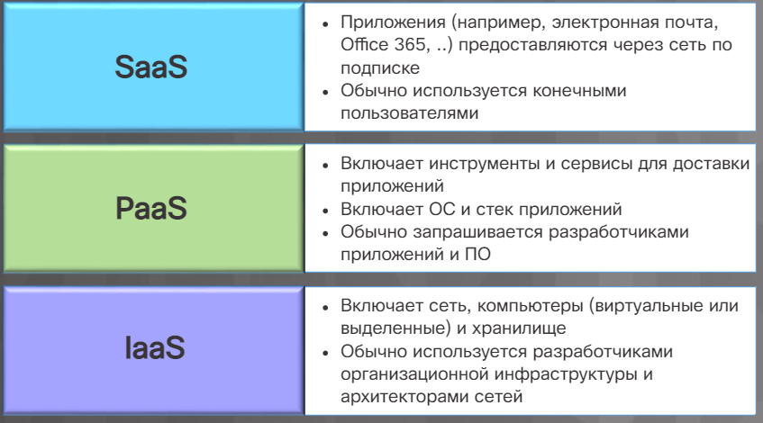

Что вы уже знаете? - Модели облака

Сценарий

Жительнице Смиттауна нужна информация с веб-сайта Министерства транспорта, чтобы лучше понять, как повлияет планируемый новый торговый центр на дорожную ситуацию в ее сообществе. Узнав, что интенсивность дорожного движения может увеличиться вдвое, она оставляет публичный комментарий с протестом против строительства.

Гибридный.облако состоит из облаков двух или более типов (например, частного и общедоступного). Каждая часть является отдельным объектом, но все части связаны единой архитектурой. Организации могут использовать частное облако для обмена конфиденциальной информацией, а общедоступное облако -для размещения общего контента для клиентов. В данном примере жительница может использовать частное облако Министерства транспорта только для получения информации, а общедоступную часть - для размещения отзыва. Пользователи гибридного облака обладают разными уровнями доступа к сервисам в зависимости от своих прав. Гибридное облако может использовать организация для предоставления сервисов в ходе кратковременных всплесков трафика.

Сценарий

Боб приезжает в свой офис в Министерстве транспорта. Он входит в систему на своем компьютере и просматривает бюджетную смету на асфальтовое покрытие, необходимое для расширения дороги в связи с планируемым строительством нового торгового центра.

Частный.Частные облака создаются специально для организации или юридического лица. Примеры организаций, использующих частные облака: поставщики услуг, финансовые, медицинские учреждения и др. Частное облако можно создать с использованием частной сети организации. Однако его создание и обслуживание может потребовать больших затрат. Частным облаком может также управлять внешняя организация со строгой защитой доступа. Частные облака:

о Используют частные виртуальные ресурсы о Поддерживают одного клиента (организацию) о Защищают конфиденциальную информацию

Сценарий

С помощью сервиса Gmail Боб сообщает другу, что не сможет встретиться с ним после работы, так как он задерживается из-за выполнения проекта.

Выберите модель облака, которая скорее всего используется в этом сценарии.

Это облачные приложения и сервисы, предлагаемые в общедоступном облаке всем пользователям. Сервисы могут предлагаться бесплатно или с оплатой по мере использования, например за онлайн-хранилище. Для предоставления сервисов общедоступное облако использует Интернет. Общедоступные облака наиболее распространены. Примеры сервисов общедоступного облака: Gmail, Box, Dropbox, Netflix и Apple Music. Общедоступные облака:

о Используют общие виртуализированные ресурсы о Поддерживают несколько клиентов о Поддерживают подключение к Интернету

Сценарий

Андреа - руководитель проекта в компании, которая занимается асфальтовым покрытием. Она отправила коммерческое предложение на веб-сайт поставщика Министерства транспорта для строительства новой дороги, которая требуется для нового торгового центра.

Коллективный. Коллективное облако создается для исключительного использования конкретными юридическими лицами или организациями. Различие между общедоступным и коллективным облаками заключается в удовлетворении особых функциональных потребностей конкретного сообщества. Например, медицинские учреждения обязаны соблюдать политики и законы (такие как HIPAA), что требует особого уровня аутентификации и конфиденциальности. Коллективные облака используют многие организации с одинаковыми потребностями и особенностями. Коллективные облака похожи на общедоступные, но имеют характерные для частного облака определенные уровни безопасности, конфиденциальности и даже соответствия нормативным требованиям.

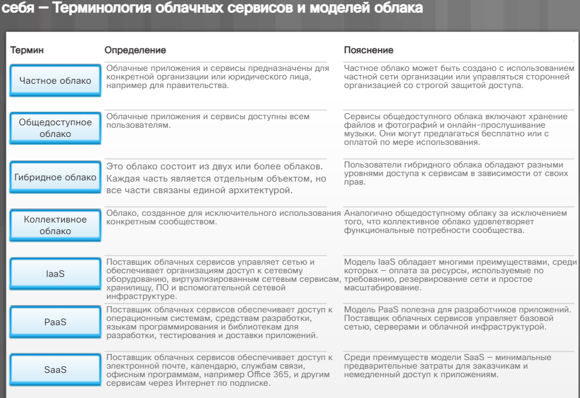

Характеристики облачных вычислений

Доступ по запросу (самообслуживание).Пользователи могут инициализировать вычислительные сервисы и вносить в них изменения по мере необходимости, не взаимодействуя с поставщиком услуг.

Эластичность.Сервисы могут предоставляться, когда они нужны, и очень быстро освобождаться, когда они больше не требуются. В некоторые случаях сервисы могут автоматически масштабироваться в зависимости от пользовательского спроса.

Пул ресурсов.Вычислительные ресурсы поставщика объединены в пул, чтобы их могли использовать несколько потребителей на основе многопользовательской модели. Каждая модель, каждый пользователь (клиент) использует физические и виртуальные ресурсы из общего пула, которые динамически назначаются и переназначаются в соответствии с потребительским спросом. Примеры ресурсов, которые могут быть объединены в пул и использоваться совместно: хранилище, процессор, память и сетевая полоса пропускания.

Сервис с возможностью измерения и учета.Облачные системы предусматривают измерения качества обслуживания, которые позволяют автоматически контролировать и оптимизировать ресурсы с помощью механизма учета. Учет можно использовать для задания пороговых значений, которые гарантируют удовлетворительные уровни обслуживания для клиента. Сервисы с возможностью измерения и учета также предоставляют отчеты для поставщика и потребителя.

Широкие возможности сетевого доступа.Доступ к сервисам осуществляется по сети с помощью смартфонов, планшетов, ноутбуков и рабочих станций.

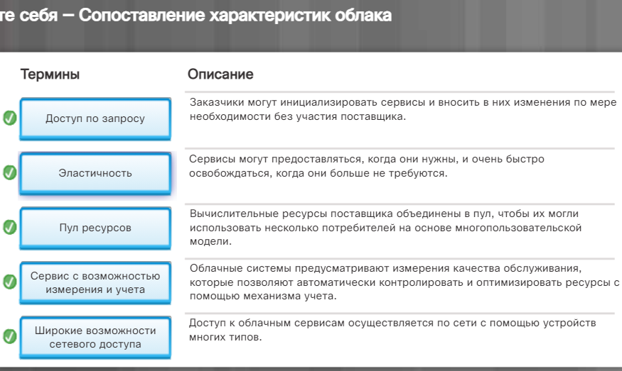

Глава 9. Виртуализация и облачные вычисления В этой главе вы узнали, что понятия «виртуализация» и «облачные вычисления» зачастую используются как взаимозаменяемые, но на самом деле они означают разные вещи. Виртуализация — это технология, которая позволяет разместить на одном физическом компьютере (хост-компьютере) несколько виртуальных компьютеров, совместно использующих оборудование хост-компьютера. Облачные вычисления — это технология, которая позволяет отделить приложения от оборудования. Виртуализация — это основа облачных вычислений.

Вы узнали, что доставка пользователям приложений и сервисов традиционным способом — с помощью выделенных серверов — неэффективна, ненадежна и не допускает масштабирования. Выделенные серверы могут простаивать длительное время, создают единую точку отказа и занимают много места. Виртуализация решает эти проблемы, объединяя множество виртуальных серверов на одном физическом сервере, позволяя использовать незадействованные ресурсы и сокращая число серверов, необходимых для предоставления сервисов пользователям. Вы узнали о многочисленных преимуществах виртуализации по сравнению с традиционным использованием выделенных серверов. Среди этих преимуществ — более эффективное использование ресурсов, сокращение требований к свободному пространству, снижение затрат, увеличение времени безотказной работы серверов и другие.

Облачные вычисления обеспечивают пользователям доступ к вычислительным сервисам по требованию через Интернет. Большинство из нас уже использует такие сервисы — это, например, онлайн-прослушивание музыки или хранение данных в Интернете. Вы узнали, какие типы облачных сервисов предлагают поставщики. SaaS обеспечивает доступ к электронной почте, календарю, службам связи, офисным программам и другим сервисам через Интернет по подписке. PaaS обеспечивает доступ к операционным системам, средствам разработки, языкам программирования и библиотекам для разработки, тестирования и доставки приложений. IaaS обеспечивает организациям доступ к сетевому оборудованию, виртуализированным сетевым сервисам, хранилищу, ПО и вспомогательной сетевой инфраструктуре.

По завершении главы вы выполнили несколько упражнений на проверку понимания терминологии и характеристик облачных вычислений.